# Generalised Linear Modelling

# Link functions

- We need a way to map (or *link*) sensible values for $\mathbb{E}(y)$ to a linear equation $a + \mathbf{BX}$
- The linear equation is defined for all real numbers: $(-\infty, \infty)$, while $\mathbb{E}(y)$ is in $[0,1]$
- For probabilities, the *logit* function works well

$$\begin{aligned}
\log \frac{p}{1-p} & = a + \mathbf{BX} \\
\mathrm{logit} (p) & = a + \mathbf{BX} \\
p & = \mathrm{logit}^{-1} (a + \mathbf{BX}) \\
p & = \frac{e^{a + \mathbf{BX}}}{1 + e^{a + \mathbf{BX}}}
\end{aligned}$$

- In R, we can use `p = plogis(a + X %*% B)`

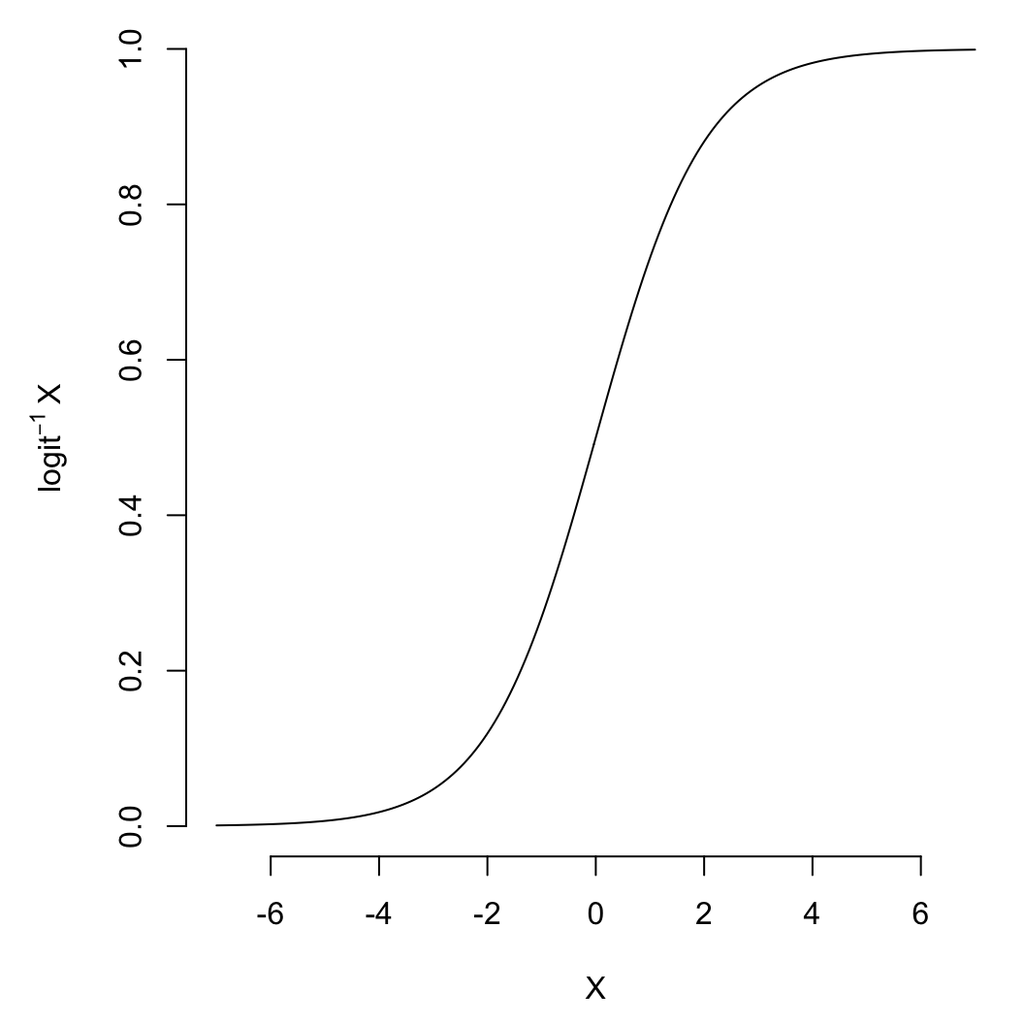

# Binomial-logistic regression

```r
log_posterior = function(params, data) {
  # parameters for the regression model
  a = params['a']
  b = params['b']
  n = data[['n']]
  died = data[['died']]
  temperature = data[['annual_mean_temp']]

  # the probability of death changes with temperature
  p = plogis(a + b*temperature)

  # liklihood
  logpr = sum(dbinom(died, n, p, log=TRUE))

  # priors
  logpr = logpr + dnorm(a, 0, 20, log=TRUE) + dnorm(b, 0, 5, log=TRUE)
  logpr
}
fit = optim(c(a=0.5, b=0), log_posterior, data = tsuga[n > 0],
            method = "Nelder-Mead", control=list(fnscale=-1), hessian=TRUE)

vcv = solve(-fit$hessian)
fit$par
```

```
##          a          b
## -1.0266212 -0.1291986
```

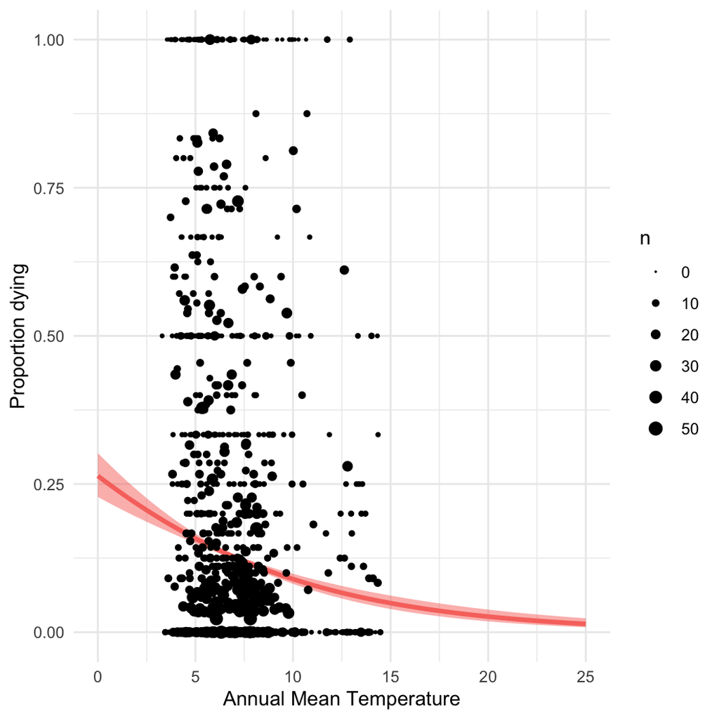

# Link functions

- More generally, we can say that our observations $y$ are drawn from some distribution $\mathcal{D}$ that has parameters $\theta$
- The distribution parameters $\theta$ are related to the expected value of $y$, $\mathbb{E}(y)$, and usually a precision/dispersion parameter $\phi$
- There exists a **link function** $\mathrm{L}(y)$ that maps the expectation of $y$ onto the linear model

$$\begin{aligned}
\mathbb{E}(y) & = \mathrm{L}^{-1}\left (a + \mathbf{B}\mathbf{X} \right )\\
\theta &= \mathcal{f}(\mathbb{E}[y], \phi)\\
y & \sim \mathcal{D}(\theta)
\end{aligned}$$

- This is the **generalised linear model**, suitable for many applied problems
- Linear regression is a special case of the GLM, where
  - $\mathcal{D}$ is a normal distribution with mean $\mathbb{E}(y)$ and constant variance $\sigma^2 = 1/phi$
  - $\mathrm{L}(y)$ is the **identity function**: $\mathrm{L}(y) = y$

# Canonical link functions

Many distributions have so-called canonical link functions

- **Normal**: identity—`mu = a + X %*% B`
- **Binomial**: logit—`p = plogis(a + X %*% B)`
- **Poisson**: log—`lambda = exp(a + X %*% B)`
- **Exponential**: inverse—`lambda = 1/(a + X %*% B)`

Other distributions have typical link functions, but need reparameterization

- **Negative Binomial**: log—`mu = exp(a + X %*% B)`
- **Beta**: logit, or probit—`mu = pnorm(a + X %*% B)`
- **Gamma**: inverse—`mu = 1/(a + X %*% B)`

# Count Data: Poisson

- For counts where the number of trials is unkown or nonsensical

$$\begin{aligned}
\lambda & = \exp(a + \mathbf{BX}) \\
y & \sim \mathrm{Poisson}(\lambda)
\end{aligned}$$

**Constraint:** $\sigma^2_{y|\mathbf{X}} = \mathbb{E}(y|\mathbf{X}) = \lambda$

- Sometimes, *exposure* varies by observation.
  - Different size plots
  - Different observation times
  - We add an exposure variable in this case, **u**
  - In traditional modelling, $\log u$ is called the *offset*

$$y \sim \mathrm{Poisson}(u\lambda)$$

# Overdispersed counts: Negative Binomial

- For counts where the mean and variance are not equal
- Typical in ecological count data (e.g., abundances)

$$\begin{aligned}
\mu & = \exp(a + \mathbf{BX}) \\
y & \sim \mathrm{NB}(\mu, \phi)
\end{aligned}$$

$\phi$ is called the dispersion parameter, and is related to the variance:

$$\sigma^2_{y|\mathbf{X}} = \mu + \frac{\mu^2}{\phi}$$

# Proportions: Beta

- When we have true proportions (i.e., a number of trials is unavailable)
- Also used for Binomial problems where the number of trials is missing/unrecorded
- If number of trials is available, **always** prefer Binomial GLM

$$\begin{aligned}
\mu & = \mathrm{logit}^{-1}(a_\rho + \mathbf{B_\rho X_\rho}) \\
\phi & = \exp(a_\phi + \mathbf{B_\phi X_\phi}) & \mathrm{\small optionally} \\
\alpha & = \mu\phi \\
\beta & = (1 - \mu)\phi \\
y & \sim \mathrm{Beta}(\alpha, \beta)
\end{aligned}$$

### Caveats & Hints

- $\phi$ is the **precision**; $\sigma^2_{y|\mathbf{X}} = \frac{\mu(1-\mu)}{\phi + 1}$
- Some software allows you to parameterise the beta directly, using $\mu$ and $\phi$
- All *observations* of $y$ must be on (0, 1). Values of exactly 0 or 1 are not allowed
- Finite mixtures can be used if the data contain 0s and 1s.
- $\alpha$: expected number of successes when sampling $\alpha + \beta$ trials
- $\beta$: expected number of failures

# Continuous, strictly positive: Gamma

- Often used for costs, waiting times
  - ecosystem services modelling
  - animal movement
  - life expectency
- Generally assume the coefficient of variation is constant
  - can relax this assumption by modelling $\phi$ as a function of covariates

$$\begin{aligned}
\mu & = \frac{1}{(a + \mathbf{B X})} & OR \\
\mu & = \exp(a + \mathbf{B X}) \\
\\
\alpha & = \frac{\mu^2}{\phi} \\
\beta & = \frac{\mu}{\phi} \\
y & \sim \mathrm{Gamma}(\alpha, \beta)
\end{aligned}$$